# Danish kings assignment

Sofie, Kristiane og Emilie

Oprettet 7. marts 2025, opdateret 24 maj 2025

```
## ℹ Using "','" as decimal and "'.'" as grouping mark. Use `read_delim()` for more control.
##
##
```

```
## # A tibble: 54 × 14
##    Foedsels_aar Foedsels_maaned Foedsels_dag Sikker_Foedsels_aar Doeds_aar
##           <dbl>           <dbl>        <dbl> <chr>                   <dbl>
##  1          908              NA           NA Usikker                   958
##  2           NA              NA           NA Usikker                   987
##  3          980              NA           NA Usikker                  1014
##  4           NA              NA           NA Usikker                  1018
##  5          995              NA           NA Sikker                   1035
##  6         1020              NA           NA Sikker                   1042
##  7         1024              NA           NA Sikker                   1047
##  8           NA              NA           NA Usikker                  1047
##  9           NA              NA           NA Usikker                  1080
## 10           NA              NA           NA Usikker                  1086
## # ℹ 44 more rows
## # ℹ 9 more variables: Doeds_maaned <dbl>, Doeds_dag <dbl>,
## #   Sikker_doeds_aar <chr>, Start_regeringsaar <dbl>, Slut_regeringsaar <dbl>,
## #   Periode <dbl>, `Sikker_start_ regeringsaar` <chr>,
## #   Sikker_slut_regeringsaar <chr>, Navn <chr>
```

The task here is to load your Danish Monarchs csv into R using the `tidyverse` toolkit, calculate and explore the kings’ duration of reign with pipes `%>%` in `dplyr` and plot it over time.

## Load the kings

Make sure to first create an `.Rproj` workspace with a `data/` folder where you place either your own dataset or the provided `kings.csv` dataset.

1. Look at the dataset that are you loading and check what its columns are separated by? (hint: open it in plain text editor to see)

List what is the

separator: the seperator is semicolon (;)

2. Create a `kings` object in R with the different functions below and inspect the different outputs.
- `read.csv()`
- `read_csv()`
- `read.csv2()`
- `read_csv2()`

```r
# FILL IN THE CODE BELOW and review the outputs
kings1 <- read.csv("data/danish_monarchs_clean.csv")
glimpse(kings1)
```

```
## Rows: 54
## Columns: 1
## $ Foedsels_aar.Foedsels_maaned.Foedsels_dag.Sikker_Foedsels_aar.Doeds_aar.Doeds_maaned.Doeds_dag.Sikker_doeds_aar.Start_regeringsaar.Slut_regeringsaar.Periode.Sikker_start_.regeringsaar.Sikker_slut_regeringsaar.Navn <chr> …
```

```r
kings2 <- read_csv("data/danish_monarchs_clean.csv")
glimpse(kings2)
```

```
## Rows: 54
## Columns: 1
## $ `Foedsels_aar;Foedsels_maaned;Foedsels_dag;Sikker_Foedsels_aar;Doeds_aar;Doeds_maaned;Doeds_dag;Sikker_doeds_aar;Start_regeringsaar;Slut_regeringsaar;Periode;Sikker_start_ regeringsaar;Sikker_slut_regeringsaar;Navn` <chr> …
```

```r
kings3 <- read.csv2("data/danish_monarchs_clean.csv")
glimpse(kings3)
```

```
## Rows: 54
## Columns: 14
## $ Foedsels_aar               <int> 908, NA, 980, NA, 995, 1020, 1024, NA, NA, …
## $ Foedsels_maaned            <int> NA, NA, NA, NA, NA, NA, NA, NA, NA, NA, NA,…
## $ Foedsels_dag               <int> NA, NA, NA, NA, NA, NA, NA, NA, NA, NA, NA,…
## $ Sikker_Foedsels_aar        <chr> "Usikker", "Usikker", "Usikker", "Usikker",…
## $ Doeds_aar                  <int> 958, 987, 1014, 1018, 1035, 1042, 1047, 104…
## $ Doeds_maaned               <int> NA, NA, NA, NA, NA, NA, NA, 4, NA, 10, NA, …
## $ Doeds_dag                  <int> NA, NA, NA, NA, NA, NA, NA, 28, NA, 7, NA, …
## $ Sikker_doeds_aar           <chr> "Sikker", "Sikker", "Sikker", "Sikker", "Si…
## $ Start_regeringsaar         <int> 936, NA, NA, 1014, 1018, 1035, 1042, 1047, …
## $ Slut_regeringsaar          <int> 958, 987, 1014, 1018, 1035, 1042, 1047, 107…
## $ Periode                    <int> 22, NA, NA, 4, 17, 7, 5, 27, 6, 6, 9, 8, 30…
## $ Sikker_start_.regeringsaar <chr> "Sikker", "Usikker", "Usikker", "Sikker", "…
## $ Sikker_slut_regeringsaar   <chr> "Sikker", "Sikker", "Sikker", "Sikker", "Si…
## $ Navn                       <chr> "Gorm_Den_Gamle", "Harald_1_Blaatand", "Sve…
```

```r
kings4 <- read_csv2( "data/danish_monarchs_clean.csv")
```

```
## ℹ Using "','" as decimal and "'.'" as grouping mark. Use `read_delim()` for more control.
```

```r
glimpse(kings4)
```

```
## Rows: 54
## Columns: 14
## $ Foedsels_aar                 <dbl> 908, NA, 980, NA, 995, 1020, 1024, NA, NA…
## $ Foedsels_maaned              <dbl> NA, NA, NA, NA, NA, NA, NA, NA, NA, NA, N…
## $ Foedsels_dag                 <dbl> NA, NA, NA, NA, NA, NA, NA, NA, NA, NA, N…
## $ Sikker_Foedsels_aar          <chr> "Usikker", "Usikker", "Usikker", "Usikker…
## $ Doeds_aar                    <dbl> 958, 987, 1014, 1018, 1035, 1042, 1047, 1…
## $ Doeds_maaned                 <dbl> NA, NA, NA, NA, NA, NA, NA, 4, NA, 10, NA…
## $ Doeds_dag                    <dbl> NA, NA, NA, NA, NA, NA, NA, 28, NA, 7, NA…
## $ Sikker_doeds_aar             <chr> "Sikker", "Sikker", "Sikker", "Sikker", "…
## $ Start_regeringsaar           <dbl> 936, NA, NA, 1014, 1018, 1035, 1042, 1047…
## $ Slut_regeringsaar            <dbl> 958, 987, 1014, 1018, 1035, 1042, 1047, 1…
## $ Periode                      <dbl> 22, NA, NA, 4, 17, 7, 5, 27, 6, 6, 9, 8, …
## $ `Sikker_start_ regeringsaar` <chr> "Sikker", "Usikker", "Usikker", "Sikker",…
## $ Sikker_slut_regeringsaar     <chr> "Sikker", "Sikker", "Sikker", "Sikker", "…
## $ Navn                         <chr> "Gorm_Den_Gamle", "Harald_1_Blaatand", "S…
```

Answer: 1. Which of these functions is a `tidyverse` function? read_csv2 is a ‘tidyverse’ function.

```r
class(kings1)
```

```
## [1] "data.frame"
```

```r
class(kings2)
```

```
## [1] "spec_tbl_df" "tbl_df"      "tbl"         "data.frame"
```

```r
class(kings3)
```

```
## [1] "data.frame"
```

```r
class(kings4)
```

```
## [1] "spec_tbl_df" "tbl_df"      "tbl"         "data.frame"
```

```r
# COMPLETE THE BLANKS BELOW WITH YOUR CODE, then turn the 'eval' flag in this chunk to TRUE.

kings <- kings4

class(kings)
```

```
## [1] "spec_tbl_df" "tbl_df"      "tbl"         "data.frame"
```

```r
ncol(kings)
```

```
## [1] 14
```

```r
glimpse(kings)
```

```
## Rows: 54
## Columns: 14
## $ Foedsels_aar                 <dbl> 908, NA, 980, NA, 995, 1020, 1024, NA, NA…
## $ Foedsels_maaned              <dbl> NA, NA, NA, NA, NA, NA, NA, NA, NA, NA, N…
## $ Foedsels_dag                 <dbl> NA, NA, NA, NA, NA, NA, NA, NA, NA, NA, N…
## $ Sikker_Foedsels_aar          <chr> "Usikker", "Usikker", "Usikker", "Usikker…
## $ Doeds_aar                    <dbl> 958, 987, 1014, 1018, 1035, 1042, 1047, 1…
## $ Doeds_maaned                 <dbl> NA, NA, NA, NA, NA, NA, NA, 4, NA, 10, NA…
## $ Doeds_dag                    <dbl> NA, NA, NA, NA, NA, NA, NA, 28, NA, 7, NA…
## $ Sikker_doeds_aar             <chr> "Sikker", "Sikker", "Sikker", "Sikker", "…
## $ Start_regeringsaar           <dbl> 936, NA, NA, 1014, 1018, 1035, 1042, 1047…
## $ Slut_regeringsaar            <dbl> 958, 987, 1014, 1018, 1035, 1042, 1047, 1…
## $ Periode                      <dbl> 22, NA, NA, 4, 17, 7, 5, 27, 6, 6, 9, 8, …
## $ `Sikker_start_ regeringsaar` <chr> "Sikker", "Usikker", "Usikker", "Sikker",…
## $ Sikker_slut_regeringsaar     <chr> "Sikker", "Sikker", "Sikker", "Sikker", "…
## $ Navn                         <chr> "Gorm_Den_Gamle", "Harald_1_Blaatand", "S…
```

## Calculate the duration of reign for all the kings in your table

You can calculate the duration of reign in years with `mutate` function by subtracting the equivalents of your `startReign` from `endReign` columns and writing the result to a new column called `duration`. But first you need to check a few things:

- Is your data messy? Fix it before re-importing to R
- Do your start and end of reign columns contain NAs? Choose the right strategy to deal with them: `na.omit()`, `na.rm=TRUE`, `!is.na()`

Create a new column called `duration` in the kings dataset, utilizing the `mutate()` function from tidyverse. Check with your group to brainstorm the options.

We already have a column that shows the duration of reign called ‘Periode’. But we will show below how we use the mutate function to create a new column called ‘duration’ in the kings dataset.

```r
# YOUR CODE

kings <- kings %>%
  mutate(duration = Slut_regeringsaar - Start_regeringsaar)

glimpse(kings)
```

```
## Rows: 54
## Columns: 15
## $ Foedsels_aar                 <dbl> 908, NA, 980, NA, 995, 1020, 1024, NA, NA…
## $ Foedsels_maaned              <dbl> NA, NA, NA, NA, NA, NA, NA, NA, NA, NA, N…
## $ Foedsels_dag                 <dbl> NA, NA, NA, NA, NA, NA, NA, NA, NA, NA, N…
## $ Sikker_Foedsels_aar          <chr> "Usikker", "Usikker", "Usikker", "Usikker…
## $ Doeds_aar                    <dbl> 958, 987, 1014, 1018, 1035, 1042, 1047, 1…
## $ Doeds_maaned                 <dbl> NA, NA, NA, NA, NA, NA, NA, 4, NA, 10, NA…
## $ Doeds_dag                    <dbl> NA, NA, NA, NA, NA, NA, NA, 28, NA, 7, NA…
## $ Sikker_doeds_aar             <chr> "Sikker", "Sikker", "Sikker", "Sikker", "…
## $ Start_regeringsaar           <dbl> 936, NA, NA, 1014, 1018, 1035, 1042, 1047…
## $ Slut_regeringsaar            <dbl> 958, 987, 1014, 1018, 1035, 1042, 1047, 1…
## $ Periode                      <dbl> 22, NA, NA, 4, 17, 7, 5, 27, 6, 6, 9, 8, …
## $ `Sikker_start_ regeringsaar` <chr> "Sikker", "Usikker", "Usikker", "Sikker",…
## $ Sikker_slut_regeringsaar     <chr> "Sikker", "Sikker", "Sikker", "Sikker", "…
## $ Navn                         <chr> "Gorm_Den_Gamle", "Harald_1_Blaatand", "S…
## $ duration                     <dbl> 22, NA, NA, 4, 17, 7, 5, 27, 6, 6, 9, 8, …
```

## Calculate the average duration of reign for all rulers

Do you remember how to calculate an average on a vector object? If not, review the last two lessons and remember that a column is basically a vector. So you need to subset your `kings` dataset to the `duration` column. If you subset it as a vector you can calculate average on it with `mean()` base-R function. If you subset it as a tibble, you can calculate average on it with `summarize()` tidyverse function. Try both ways!

- You first need to know how to select the relevant `duration` column. What are your options?
- If your selected `duration` column a tibble or a vector? The `mean()` function can only be run on a vector. The `summarize()` function works on a tibble.
- Are you getting an error that there are characters in your column? Coerce your data to numbers with `as.numeric()`.
- Remember to handle NAs: `mean(X, na.rm=TRUE)`

As seen below we have tried to use both the mean() base-R function and the`summarize()` tidyverse function. Both functions give us the same result: The average duration of reign of all rulers is 19.9 years.

```r
# YOUR CODE
kings_duration <- c(kings$duration)
kings_duration
```

```
##  [1] 22 NA NA  4 17  7  5 27  6  6  9  8 30  3  9 11 25 20 39  9  2  7 27 33  6
## [26]  3  3 35 12  9 43  8 33 31 10 10 23 29 60 22 29 31 16 20 42 31  9 15 43  6
## [51] 35 25 52 NA
```

```r
mean(kings_duration, na.rm = TRUE)
```

```
## [1] 19.94118
```

```r
kings_duration_tibble <- kings %>%
  select(duration)
kings_duration_tibble
```

```
## # A tibble: 54 × 1
##    duration
##       <dbl>
##  1       22
##  2       NA
##  3       NA
##  4        4
##  5       17
##  6        7
##  7        5
##  8       27
##  9        6
## 10        6
## # ℹ 44 more rows
```

```r
kings_duration_tibble %>%
  summarise(mean_duration = mean(duration, na.rm = TRUE))
```

```
## # A tibble: 1 × 1
##   mean_duration
##           <dbl>
## 1          19.9
```

## How many and which kings enjoyed a longer-than-average duration of reign?

You have calculated the average duration above. Use it now to `filter()` the `duration` column in `kings` dataset. Display the result and also count the resulting rows with `count()`

By using the code below, we have come to the conclusion that 25 kings enjoyed a longer-than-averiage duration of reign. Under Step 2 we have created a tibble with the names of the 25 kings.

```r
# YOUR CODE
# Step 1: Calculate the average duration
mean_duration <- mean(kings$duration, na.rm = TRUE)

# Step 2: Filter kings with a longer-than-average duration
longer_than_average_kings <- kings %>%
  filter(duration > mean_duration) %>%
  select(Navn)

print(longer_than_average_kings)
```

```
## # A tibble: 25 × 1
##    Navn
##    <chr>
##  1 Gorm_Den_Gamle
##  2 Svend_2_Estridsen
##  3 Niels
##  4 Valdemar_1_Den_Store
##  5 Knud_4
##  6 Valdemar_2_Sejr
##  7 Erik_5_Klipping
##  8 Erik_6_Menved
##  9 Valdemar_4_Atterdag
## 10 Erik_7_Pommern
## # ℹ 15 more rows
```

```r
# Step 3: Count the resulting rows
longer_than_average_kings_count <- longer_than_average_kings %>%
  count()

# Step 4: Display the count
print(longer_than_average_kings_count)
```

```
## # A tibble: 1 × 1
##       n
##   <int>
## 1    25
```

## How many days did the three longest-ruling monarchs rule?

- Sort kings by reign `duration` in the descending order. Select the three longest-ruling monarchs with the `slice()` function
- Use `mutate()` to create `Days` column where you calculate the total number of days they ruled
- BONUS: consider the transition year (with 366 days) in your calculation!

The three longest-ruling monarchs is: Christian 4.: 60 years or 21901 days. Margrethe 2.: 52 years or 18981 Erik 7. Pommern: 43 years or 15695 days.

```r
# YOUR CODE
# Step 1: Sort kings by duration in descending order and select top 3
top_3_kings <- kings %>%
  arrange(desc(duration)) %>%
  slice(1:3)
top_3_kings
```

```
## # A tibble: 3 × 15
##   Foedsels_aar Foedsels_maaned Foedsels_dag Sikker_Foedsels_aar Doeds_aar
##          <dbl>           <dbl>        <dbl> <chr>                   <dbl>
## 1         1577               4           12 Sikker                   1648
## 2         1940               4           16 Sikker                     NA
## 3         1382              NA           NA Sikker                   1459
## # ℹ 10 more variables: Doeds_maaned <dbl>, Doeds_dag <dbl>,
## #   Sikker_doeds_aar <chr>, Start_regeringsaar <dbl>, Slut_regeringsaar <dbl>,
## #   Periode <dbl>, `Sikker_start_ regeringsaar` <chr>,
## #   Sikker_slut_regeringsaar <chr>, Navn <chr>, duration <dbl>
```

```r
top_3_kings_with_days <- top_3_kings %>%
  mutate(Days = duration * 365 + ifelse(Periode %% 4 == 0 & (Periode %% 100 != 0 | Periode %% 400 == 0), 1, 0))

print(top_3_kings_with_days)
```

```
## # A tibble: 3 × 16
##   Foedsels_aar Foedsels_maaned Foedsels_dag Sikker_Foedsels_aar Doeds_aar
##          <dbl>           <dbl>        <dbl> <chr>                   <dbl>
## 1         1577               4           12 Sikker                   1648
## 2         1940               4           16 Sikker                     NA
## 3         1382              NA           NA Sikker                   1459
## # ℹ 11 more variables: Doeds_maaned <dbl>, Doeds_dag <dbl>,
## #   Sikker_doeds_aar <chr>, Start_regeringsaar <dbl>, Slut_regeringsaar <dbl>,
## #   Periode <dbl>, `Sikker_start_ regeringsaar` <chr>,
## #   Sikker_slut_regeringsaar <chr>, Navn <chr>, duration <dbl>, Days <dbl>
```

## Challenge: Plot the kings’ duration of reign through time

- Try to plot the duration of reign column in `ggplot` with `geom_point()` and `geom_smooth()`
- In order to peg the duration (which is between 1-99) somewhere to the x axis with individual centuries, I recommend creating a new column `midyear` by adding to `startYear` the product of `endYear` minus the `startYear` divided by two (`startYear + (endYear-startYear)/2`).
- Now you can plot the kings dataset, plotting `midyear` along the x axis and `duration` along y axis
- BONUS: add a title, nice axis labels to the plot and make the theme B&W and font bigger to make it nice and legible!

```r
# YOUR CODE
# Step 1: Create the 'midyear' column
kings <- kings %>%
  mutate(midyear = Start_regeringsaar + (Slut_regeringsaar - Start_regeringsaar) / 2)

glimpse(kings)
```

```
## Rows: 54
## Columns: 16
## $ Foedsels_aar                 <dbl> 908, NA, 980, NA, 995, 1020, 1024, NA, NA…
## $ Foedsels_maaned              <dbl> NA, NA, NA, NA, NA, NA, NA, NA, NA, NA, N…
## $ Foedsels_dag                 <dbl> NA, NA, NA, NA, NA, NA, NA, NA, NA, NA, N…
## $ Sikker_Foedsels_aar          <chr> "Usikker", "Usikker", "Usikker", "Usikker…
## $ Doeds_aar                    <dbl> 958, 987, 1014, 1018, 1035, 1042, 1047, 1…
## $ Doeds_maaned                 <dbl> NA, NA, NA, NA, NA, NA, NA, 4, NA, 10, NA…
## $ Doeds_dag                    <dbl> NA, NA, NA, NA, NA, NA, NA, 28, NA, 7, NA…
## $ Sikker_doeds_aar             <chr> "Sikker", "Sikker", "Sikker", "Sikker", "…
## $ Start_regeringsaar           <dbl> 936, NA, NA, 1014, 1018, 1035, 1042, 1047…
## $ Slut_regeringsaar            <dbl> 958, 987, 1014, 1018, 1035, 1042, 1047, 1…
## $ Periode                      <dbl> 22, NA, NA, 4, 17, 7, 5, 27, 6, 6, 9, 8, …
## $ `Sikker_start_ regeringsaar` <chr> "Sikker", "Usikker", "Usikker", "Sikker",…
## $ Sikker_slut_regeringsaar     <chr> "Sikker", "Sikker", "Sikker", "Sikker", "…
## $ Navn                         <chr> "Gorm_Den_Gamle", "Harald_1_Blaatand", "S…
## $ duration                     <dbl> 22, NA, NA, 4, 17, 7, 5, 27, 6, 6, 9, 8, …
## $ midyear                      <dbl> 947.0, NA, NA, 1016.0, 1026.5, 1038.5, 10…
```

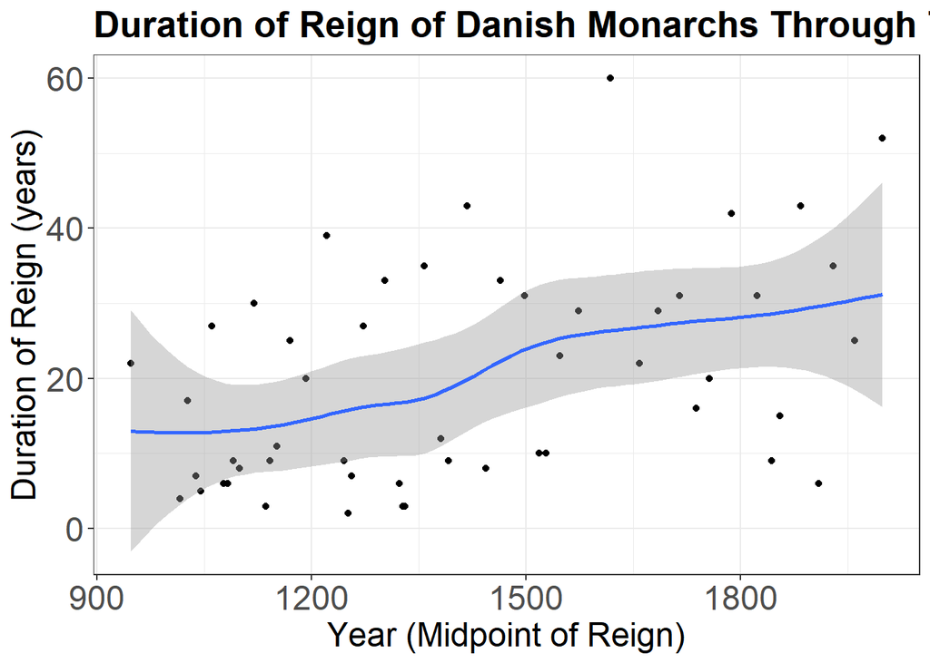

```r
# Step 2: Plot the duration of reign with ggplot
duration_of_reign_danish_monarchs <- ggplot(kings,aes(x=midyear,y=duration)) +
  geom_point() +
  geom_smooth() +
  labs(
    title = "Duration of Reign of Danish Monarchs Through Time",
    x = "Year (Midpoint of Reign)",
    y = "Duration of Reign (years)"
  ) +
  theme_bw() +
theme(
    plot.title = element_text(size = 20, face = "bold"),
    axis.title.x = element_text(size = 18),
    axis.title.y = element_text(size = 18),
    axis.text.x = element_text(size = 18),
    axis.text.y = element_text(size = 18)
  )


# Step 3: See the result
duration_of_reign_danish_monarchs
```

```r
ggsave("figures/duration_of_reign_danish_monarchs.png", duration_of_reign_danish_monarchs , width = 15, height = 10)
```

And to submit this rmarkdown, knit it into html. But first, clean up the code chunks, adjust the date, rename the author and change the `eval=FALSE` flag to `eval=TRUE` so your script actually generates an output. Well done!